# analysis

Joel Larwood

23/03/2020

First I am going to install the tidyverse package

```r
library(tidyverse)
library(here)
library(readxl)
library(janitor)
```

Now I will import the data

```r
data <- readxl::read_xlsx(here::here("data", "facebook_data.xlsx")) %>%
  janitor::clean_names() %>%
  dplyr::select(-id)

names(data)
```

```
##   [1] "cond"                  "gender"                "age"
##   [4] "education"             "employed"              "active_fbuse"
##   [7] "church"                "church_sspk2wk"        "class"
##  [10] "class_sspk2wk"         "cl_klike"              "close_fb_friends"
##  [13] "closefriends"          "closefriends_sspk2wk"  "cmnt_frs_posts"
##  [16] "cort_t1"               "cort_t2"               "cort_t3"
##  [19] "face_face_sunday_hrs"  "fb_communicate_mnthly" "fb_chat"
##  [22] "f_bfor_events"         "fb_friends"            "games_fbdlyh_rs"
##  [25] "h_rs_daily_all"        "h_rs_daily_fb"         "lifesatisf1"
##  [28] "lifesatisf2"           "logon_fb"              "negwords"
##  [31] "p_stress1"             "p_stress2"             "panas01"
##  [34] "panas02"               "panas03"               "panas04"
##  [37] "panas05"               "panas06"               "panas07"
##  [40] "panas08"               "panas09"               "panas10"
##  [43] "panas11"               "panas12"               "panas13"
```

[output cut: 40 more lines]

Now I want to create scores for my variables

PANAS psotive is items 1, 3, 5, 9, 10, 12, 14, 16, 17

```r
data_vars_created <- data %>%
  mutate(t1_panas_pos = rowSums(select(data,
                                       panas01,
                                       panas03,
                                       panas05,
                                       panas09,
                                       panas10,
                                       panas12,
                                       panas14,
                                       panas16,
                                       panas17))) %>%
  rowid_to_column(var = "id") # add id column to the data based of the row number

data_vars_created %>% # use the data frame called data
  select(t1_panas_pos, #keeo thge t1_panas_pos variable
         id) %>% # keep the id variable
  glimpse()
```

```
## Observations: 138
## Variables: 2
## $ t1_panas_pos <dbl> 19, 23, 31, 23, 32, 23, 30, 24, 15, 24, 25, 27, 19, 26, …
## $ id           <int> 1, 2, 3, 4, 5, 6, 7, 8, 9, 10, 11, 12, 13, 14, 15, 16, 1…
```

```r
select_vars <- data_vars_created %>%
  select(age,
         gender,
         education,
         active_fbuse,
         t1_panas_pos,
         cort_t1)

glimpse(select_vars)
```

```
## Observations: 138
## Variables: 6
## $ age          <dbl> 18, 21, 18, 21, 19, 18, 18, 19, 21, 18, 21, 22, 22, 23, …
## $ gender       <dbl> 1, 2, 1, 1, 1, 1, 1, 2, 2, 2, 2, 2, 2, 1, 1, 2, 2, 1, 2,…
## $ education    <dbl> 3, 3, 2, 4, NA, 2, NA, 4, 2, 3, 3, 3, 2, 3, 4, 5, 4, 5, …
## $ active_fbuse <dbl> 5.4, 3.8, 5.4, 2.8, 4.8, 6.0, 6.2, 3.4, 4.8, 6.4, 5.6, 5…
## $ t1_panas_pos <dbl> 19, 23, 31, 23, 32, 23, 30, 24, 15, 24, 25, 27, 19, 26, …
## $ cort_t1      <dbl> 6.15, 11.96, 3.70, 6.81, 9.28, 9.45, NA, 40.69, 5.82, 10…
```

So now that we have the variables we want to analyse lets look at how much missing data there is and also the distributions

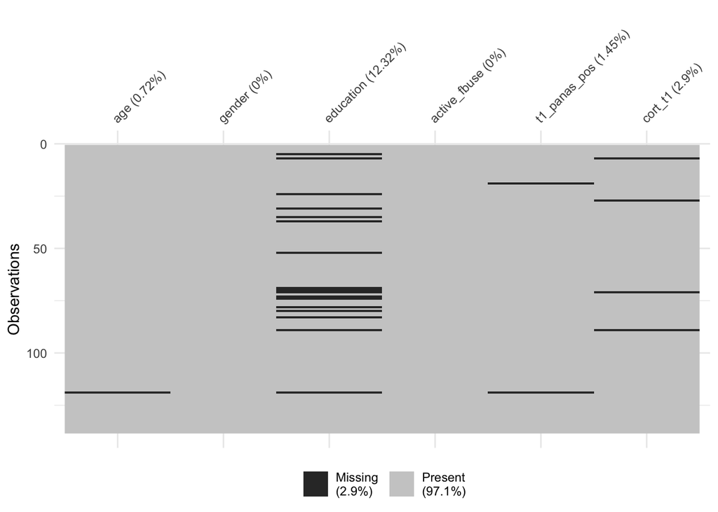

```r
library(visdat)

visdat::vis_miss(select_vars)
```

Missing data is not a concern. Lkets look at the histograms

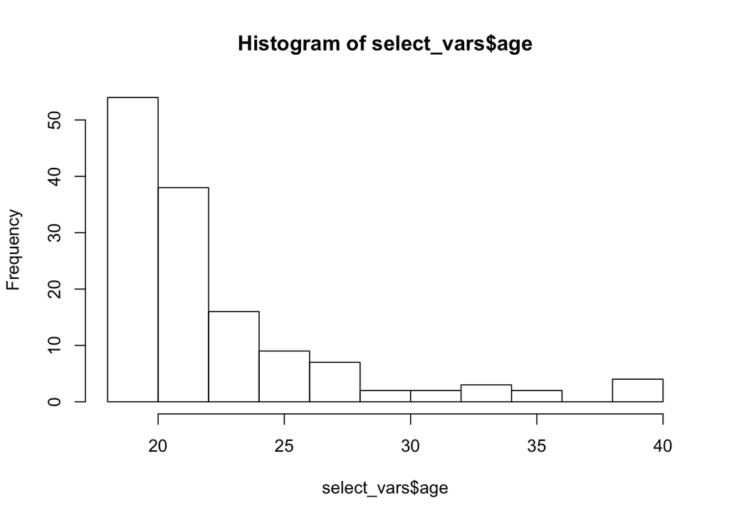

```r
hist(select_vars$age)
```

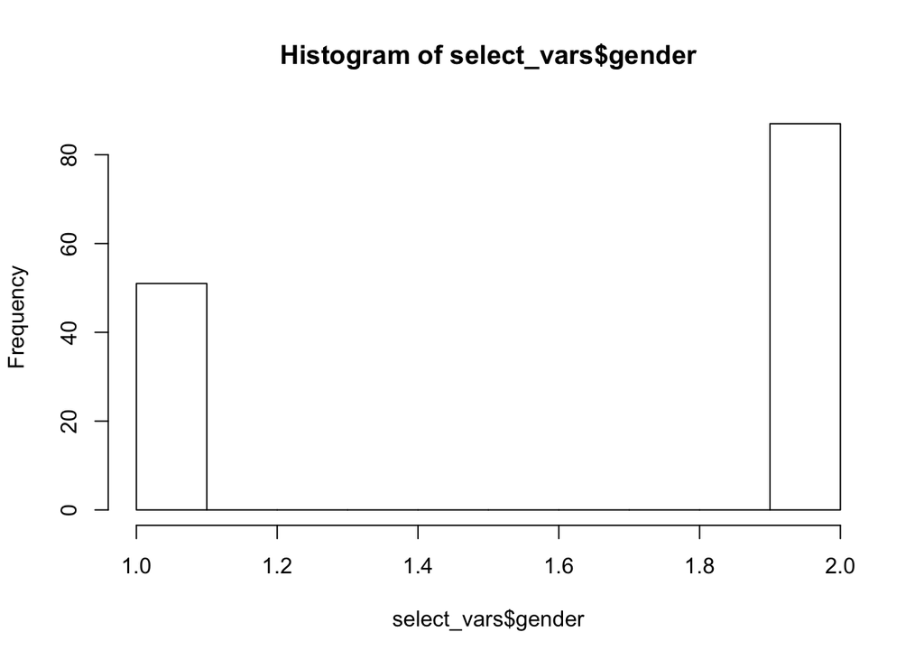

```r
hist(select_vars$gender)
```

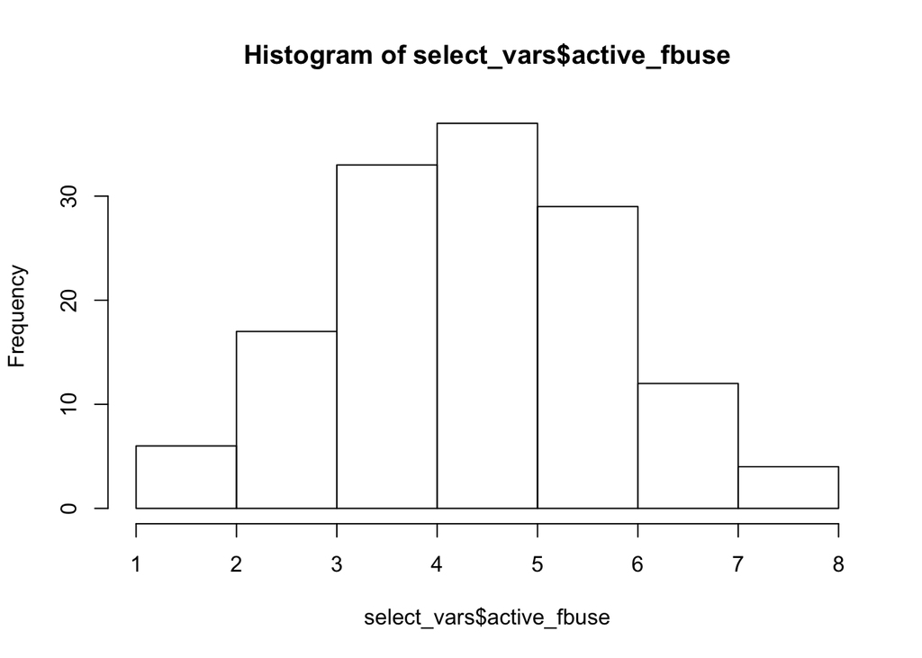

```r
hist(select_vars$active_fbuse)
```

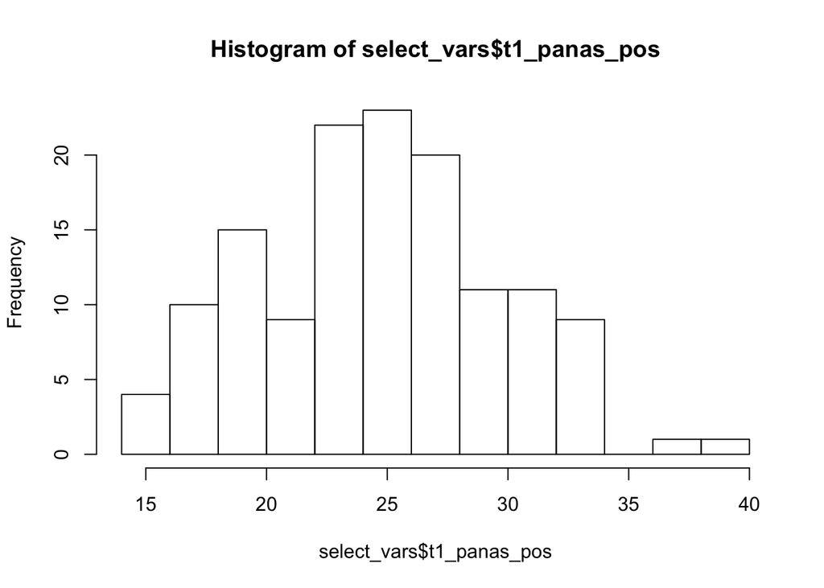

```r
hist(select_vars$t1_panas_pos)
```

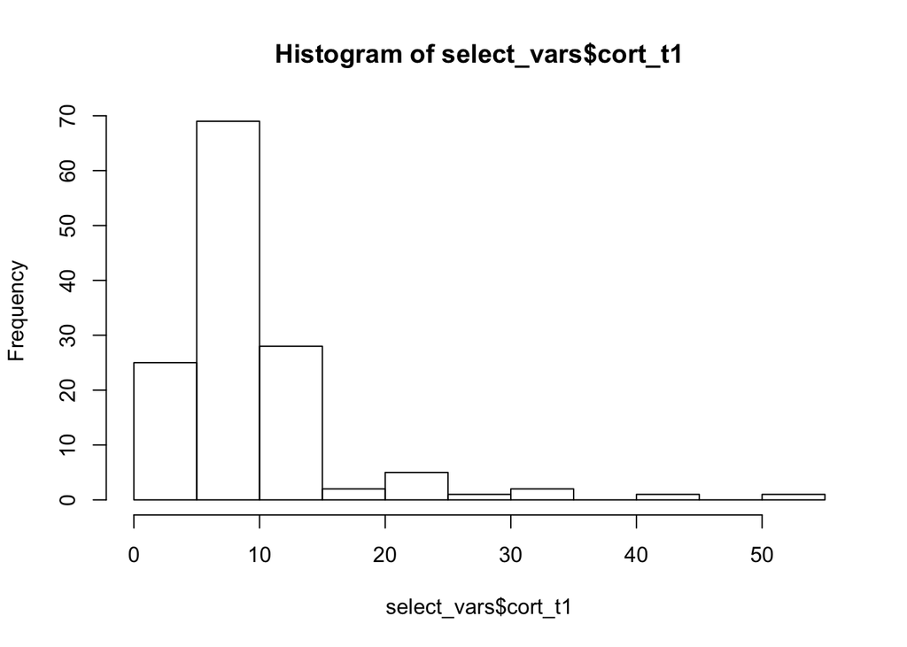

```r
hist(select_vars$cort_t1)
```

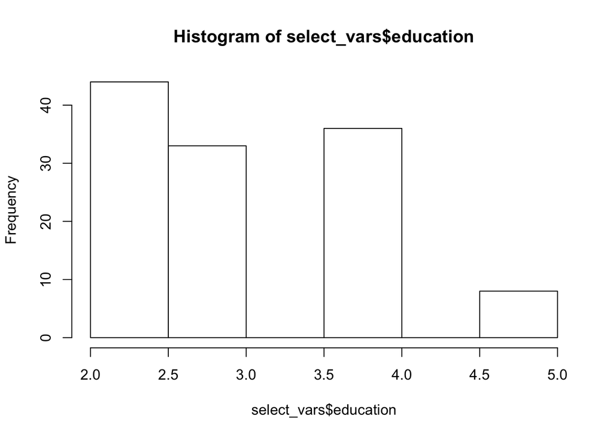

```r
hist(select_vars$education)
```

So theres some issues in the data. We don’t know which value is male and which is female. The cortisol is also skewed.

Here we want to created new/fixed variables and we can use `mutate` to do that

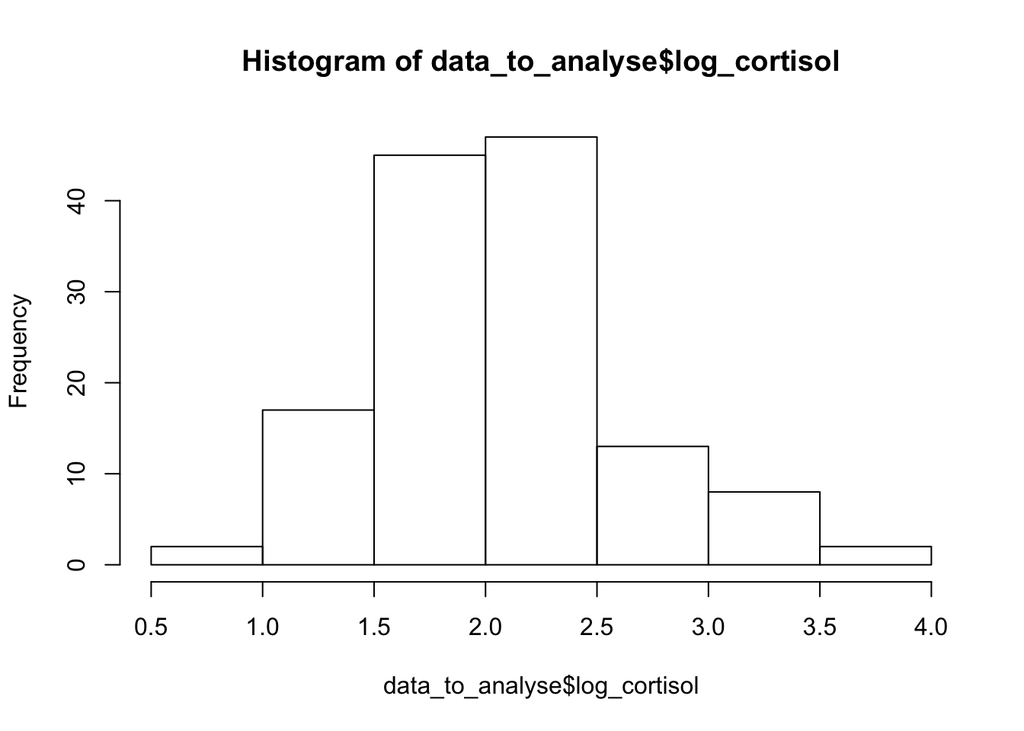

```r
data_to_analyse <- select_vars %>%
  mutate(log_cortisol = log(select_vars$cort_t1),
         gender_cat = if_else(select_vars$gender == 1,
                              "male",
                              "female"))


hist(data_to_analyse$log_cortisol) # get the histogram for the new cortisol values
```

```r
str(data_to_analyse$gender)
```

```
##  num [1:138] 1 2 1 1 1 1 1 2 2 2 ...
```

```r
str(data_to_analyse$gender_cat)
```

```
##  chr [1:138] "male" "female" "male" "male" "male" "male" "male" "female" ...
```

```r
library(apaTables)

data_to_analyse %>%
  select(log_cortisol,
         t1_panas_pos,
         active_fbuse,
         age) %>%
 apa.cor.table(filename = here::here("output", "correlations.rtf"))
```

```
##
##
## Means, standard deviations, and correlations with confidence intervals
##
##
##   Variable        M     SD   1           2           3
##   1. log_cortisol 2.07  0.55
##
##   2. t1_panas_pos 25.18 4.96 .08
##                              [-.09, .25]
##
##   3. active_fbuse 4.46  1.34 -.06        .12
##                              [-.23, .11] [-.05, .28]
##
##   4. age          22.43 4.83 -.14        -.07        -.15
##                              [-.30, .03] [-.23, .10] [-.31, .02]
##
##
## Note. M and SD are used to represent mean and standard deviation, respectively.
## Values in square brackets indicate the 95% confidence interval.
## The confidence interval is a plausible range of population correlations
## that could have caused the sample correlation (Cumming, 2014).
## * indicates p < .05. ** indicates p < .01.
##
```

Formula for regression in R is pretty trhe same as a hand written regression.

DV ~ Predictor1 + Predictor2 + Predictor3 + Predictor2*Predictor3

```r
library(interactions)
library(sjPlot)
reg1 <- lm(log_cortisol ~ gender_cat,
           data = data_to_analyse)

reg2 <- lm(log_cortisol ~ gender_cat + age,
           data = data_to_analyse)

reg3 <- lm(log_cortisol ~ gender_cat + age + t1_panas_pos,
           data = data_to_analyse)

reg4 <- lm(log_cortisol ~ gender_cat + age + t1_panas_pos + active_fbuse,
           data = data_to_analyse)


sjPlot::tab_model(reg1, reg2, reg2, reg3, reg4,
                  show.std = TRUE,
                  show.aic = TRUE)
```

|  | log cortisol |  |  |  |  | log cortisol |  |  |  |  | log cortisol |  |  |  |  | log cortisol |  |  |  |  | log cortisol |  |  |  |  |
| --- | --- | --- | --- | --- | --- | --- | --- | --- | --- | --- | --- | --- | --- | --- | --- | --- | --- | --- | --- | --- | --- | --- | --- | --- | --- |
| Predictors | Estimates | std. Beta | CI | standardized CI | p | Estimates | std. Beta | CI | standardized CI | p | Estimates | std. Beta | CI | standardized CI | p | Estimates | std. Beta | CI | standardized CI | p | Estimates | std. Beta | CI | standardized CI | p |
| (Intercept) | 2.04 | -0.05 | 1.92 – 2.15 | -0.26 – 0.16 | **<0.001** | 2.39 | -0.04 | 1.94 – 2.83 | -0.26 – 0.17 | **<0.001** | 2.39 | -0.04 | 1.94 – 2.83 | -0.26 – 0.17 | **<0.001** | 2.19 | -0.04 | 1.51 – 2.86 | -0.25 – 0.17 | **<0.001** | 2.38 | -0.03 | 1.63 – 3.14 | -0.25 – 0.18 | **<0.001** |
| gender_cat [male] | 0.08 | 0.15 | -0.11 – 0.28 | -0.21 – 0.51 | 0.410 | 0.07 | 0.13 | -0.13 – 0.27 | -0.23 – 0.49 | 0.486 | 0.07 | 0.13 | -0.13 – 0.27 | -0.23 – 0.49 | 0.486 | 0.06 | 0.12 | -0.13 – 0.26 | -0.25 – 0.48 | 0.526 | 0.05 | 0.10 | -0.14 – 0.25 | -0.26 – 0.46 | 0.586 |
| age |  |  |  |  |  | -0.02 | -0.14 | -0.03 – 0.00 | -0.31 – 0.03 | 0.110 | -0.02 | -0.14 | -0.03 – 0.00 | -0.31 – 0.03 | 0.110 | -0.02 | -0.14 | -0.03 – 0.00 | -0.31 – 0.04 | 0.123 | -0.02 | -0.15 | -0.04 – 0.00 | -0.33 – 0.02 | 0.090 |
| t1_panas_pos |  |  |  |  |  |  |  |  |  |  |  |  |  |  |  | 0.01 | 0.07 | -0.01 – 0.03 | -0.10 – 0.24 | 0.431 | 0.01 | 0.08 | -0.01 – 0.03 | -0.09 – 0.25 | 0.366 |
| active_fbuse |  |  |  |  |  |  |  |  |  |  |  |  |  |  |  |  |  |  |  |  | -0.04 | -0.10 | -0.11 – 0.03 | -0.28 – 0.08 | 0.266 |
| Observations | 134 |  |  |  |  | 133 |  |  |  |  | 133 |  |  |  |  | 132 |  |  |  |  | 132 |  |  |  |  |
| R<sup>2</sup> / R<sup>2</sup> adjusted | 0.005 / -0.002 |  |  |  |  | 0.022 / 0.007 |  |  |  |  | 0.022 / 0.007 |  |  |  |  | 0.027 / 0.004 |  |  |  |  | 0.037 / 0.006 |  |  |  |  |
| AIC | 224.519 |  |  |  |  | 220.257 |  |  |  |  | 220.257 |  |  |  |  | 221.001 |  |  |  |  | 221.709 |  |  |  |  |

```r
mod_example <- lm(active_fbuse ~ gender_cat + t1_panas_pos + gender_cat*t1_panas_pos,
                  data = data_to_analyse)

sjPlot::tab_model(mod_example,
                  show.std = TRUE,
                  show.aic = TRUE)
```

|  | active fbuse |  |  |  |  |
| --- | --- | --- | --- | --- | --- |
| Predictors | Estimates | std. Beta | CI | standardized CI | p |
| (Intercept) | 3.45 | 0.08 | 1.88 – 5.02 | -0.13 – 0.29 | **<0.001** |
| gender_cat [male] | 0.29 | -0.21 | -2.08 – 2.67 | -0.56 – 0.15 | 0.808 |
| t1_panas_pos | 0.04 | 0.16 | -0.02 – 0.11 | -0.07 – 0.39 | 0.168 |
| gender_cat [male] * t1_panas_pos | -0.02 | -0.08 | -0.11 – 0.07 | -0.43 – 0.26 | 0.628 |
| Observations | 136 |  |  |  |  |
| R<sup>2</sup> / R<sup>2</sup> adjusted | 0.025 / 0.003 |  |  |  |  |
| AIC | 469.739 |  |  |  |  |

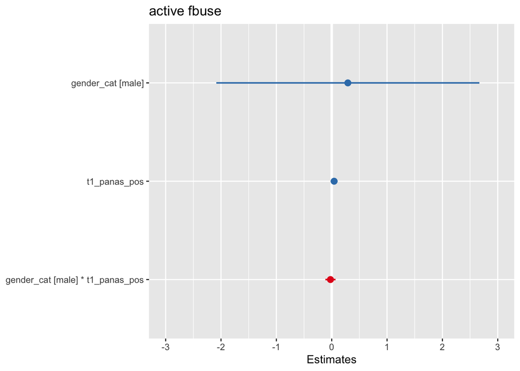

```r
sjPlot::plot_model(mod_example)
```

Hypothetically all the main effects were signinficant gender_male = .8 t1_panas_pos = 1 male*t1_panas_pos = 2

male cortisol = .8 * 1 + 1 + 2 * 1

female cortisol = .8 + 0 + 1 + 2*0